# Exercises C

Gerko Vink, Thom Volker and Erik-Jan van Kesteren

Rijkstrainees - Statistical Programming in R

# Introduction

In this practical, we will focus on two different classification methods: K-nearest neighbours and logistic regression.

One of the packages we are going to use is `class`. For this, you will probably need to `install.packages("class")` before running the `library()` functions. `ISLR` is also a new package, that needs to be installed to access the `Default` data.

```r
library(MASS)
library(magrittr)
library(class)
library(ISLR)
library(tidyverse)
library(caret)
```

Before starting with the exercises, it is a good idea to set your seed, so that (1) your answers are reproducible and (2) you can compare your answers with the answers provided.

```r
set.seed(45)
```

# Default dataset from package `ISLR`

The default dataset contains credit card loan data for 10 000 people. The goal is to classify credit card cases as `yes` or `no` based on whether they will default on their loan.

1. **Create a scatterplot of the `Default` dataset, where `balance` is mapped to the x position, `income` is mapped to the y position, and `default` is mapped to the colour. Can you see any interesting patterns already?**

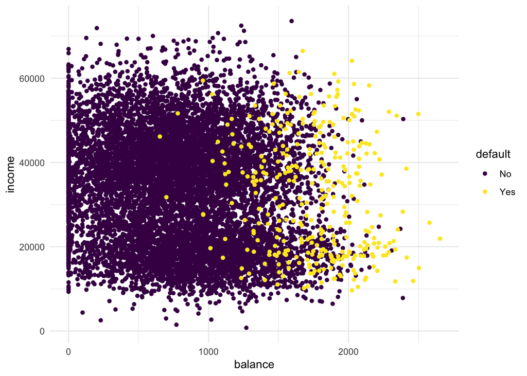

```r
ISLR::Default %>%
  arrange(default) %>% # so the yellow dots are plotted after the blue ones
  ggplot(aes(x = balance, y = income, colour = default)) +
  geom_point(size = 1.3) +
  theme_minimal() +
  scale_colour_viridis_d() # optional custom colour scale
```

It is clear that people with a larger remaining balance are more likely to default. When you look carefully, you may be able to identify two clusters in the data. One cluster for lower incomes and one cluster for higher incomes. The probability to default follows the same pattern in both clusters: higher remaining balance means an increase in probability to default.

2. **Add the line `+ facet_grid(cols = vars(student))` to the plot. What do you see?**

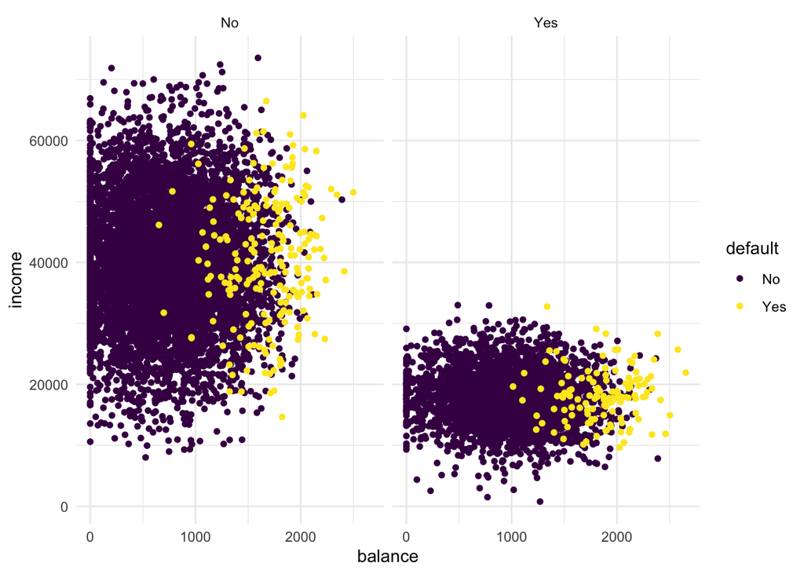

```r
Default %>%
  arrange(default) %>% # so the yellow dots are plotted after the blue ones
  ggplot(aes(x = balance, y = income, colour = default)) +
  geom_point(size = 1.3) +
  theme_minimal() +
  scale_colour_viridis_d() +
  facet_grid(cols = vars(student))
```

Clearly, if we facet the plot over students and non-students, we see that the lower income group is well-represented by the students.

3. **Transform “student” into a dummy variable using `ifelse()` (0 = not a student, 1 = student). Then, randomly split the Default dataset into a training set `train` (80%) and a test set `test` (20%).**

```r
# Create train/test split
trainIndex <- createDataPartition(Default$default, p = .8, list = FALSE)

Default %<>%
  mutate(student = ifelse(student == "Yes", 1, 0))

train <- Default[trainIndex, ]
test <- Default[-trainIndex, ]
```

# K-Nearest Neighbours

Now that we have explored the dataset, we can start on the task of classification. We can imagine a credit card company wanting to predict whether a customer will default on the loan so they can take steps to prevent this from happening.

The first method we will be using is k-nearest neighbours (KNN). It classifies datapoints based on a majority vote of the k points closest to it. In `R`, the `class` package contains a `knn()` function to perform knn.

4. **Create class predictions for the test set using the `knn()` function. Use `student`, `balance`, and `income` (but no basis functions of those variables) in the `train` dataset. Set `k` to 5. Store the predictions in a variable called `knn_5_pred`.**

```r
knn_5_pred <- knn(
  train = train %>% select(-default),
  test  = test  %>% select(-default),
  cl    = as_factor(train$default),
  k     = 5
)
```

The `knn_5_pred` object contains the predictions for the `test` data column `default`. These predictions are obtained by applying the `knn()` function on the `train` set. To be able to generate predictions, the `knn()` has been given the true classes/values (`cl`) from the training data set. The `knn()` function has not seen the true classes for the `test set.

5. **Create two scatter plots with income and balance as in the first plot you made. One with the true class (`default`) mapped to the colour aesthetic, and one with the predicted class (`knn_5_pred`) mapped to the colour aesthetic.**

*Hint: Add the predicted class `knn_5_pred` to the `test` dataset before starting your `ggplot()` call of the second plot. What do you see?*

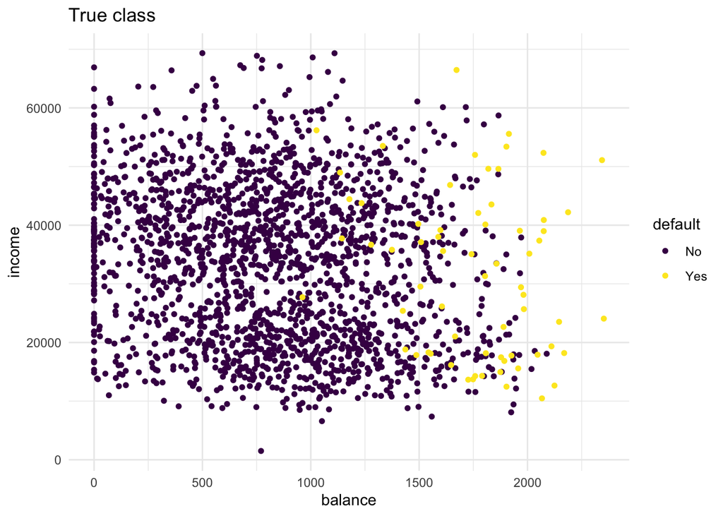

```r
# first plot is the same as before
test %>%
  arrange(default) %>%
  ggplot(aes(x = balance, y = income, colour = default)) +
  geom_point(size = 1.3) +
  scale_colour_viridis_d() +
  theme_minimal() +
  labs(title = "True class")
```

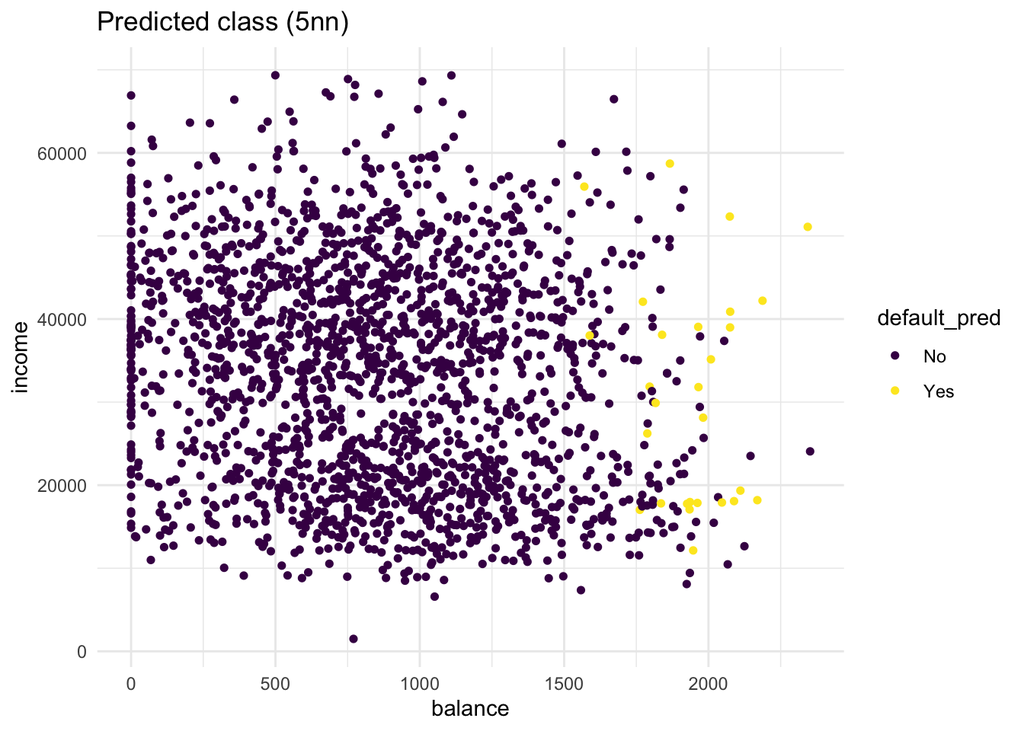

```r
# second plot maps pred to colour
bind_cols(test, default_pred = knn_5_pred) %>%
  arrange(default) %>%
  ggplot(aes(x = balance, y = income, colour = default_pred)) +
  geom_point(size = 1.3) +
  scale_colour_viridis_d() +
  theme_minimal() +
  labs(title = "Predicted class (5nn)")
```

From these plots it is clear that there are quite some misclassifications. Many `No` predictions with `Yes` as true values, and vice versa.

6. **Repeat the same steps, but now with a `knn_2_pred` vector generated from a 2-nearest neighbours algorithm. Are there any differences?**

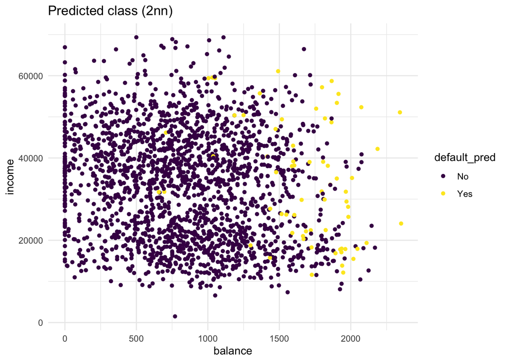

```r
knn_2_pred <- knn(
  train = train %>% select(-default),
  test  = test  %>% select(-default),
  cl    = train$default,
  k     = 2
)

# repeat the second plot from the previous exercise on the new knn predictions
bind_cols(test, default_pred = knn_2_pred) %>%
  arrange(default) %>%
  ggplot(aes(x = balance, y = income, colour = default_pred)) +
  geom_point(size = 1.3) +
  scale_colour_viridis_d() +
  theme_minimal() +
  labs(title = "Predicted class (2nn)")
```

Compared to the KNN (K=5) model, more people get classified as `Yes`. Still, the KNN (K=2) model is far from perfect. t

# Confusion matrix

The confusion matrix is an insightful summary of the plots we have made and the correct and incorrect classifications therein. A confusion matrix can be made in `R` with the `confusionMatrix()` function from the `caret` package.

```r
confusionMatrix(knn_2_pred, test$default)
```

```
## Confusion Matrix and Statistics
##
##           Reference
## Prediction   No  Yes
##        No  1885   46
##        Yes   48   20
##
##                Accuracy : 0.953
##                  95% CI : (0.9428, 0.9618)
##     No Information Rate : 0.967
##     P-Value [Acc > NIR] : 0.9996
##
##                   Kappa : 0.2742
##
##  Mcnemar's Test P-Value : 0.9179
##
##             Sensitivity : 0.9752
##             Specificity : 0.3030
##          Pos Pred Value : 0.9762
##          Neg Pred Value : 0.2941
##              Prevalence : 0.9670
##          Detection Rate : 0.9430
##    Detection Prevalence : 0.9660
##       Balanced Accuracy : 0.6391
##
##        'Positive' Class : No
##
```

7. **What would this confusion matrix look like if the classification were perfect?**

If the classification would be perfect, the confusion matrix would be:

```
## Confusion Matrix and Statistics
##
##           Reference
## Prediction   No  Yes
##        No  1933    0
##        Yes    0   66
##
##                Accuracy : 1
##                  95% CI : (0.9982, 1)
##     No Information Rate : 0.967
##     P-Value [Acc > NIR] : < 2.2e-16
##
##                   Kappa : 1
##
##  Mcnemar's Test P-Value : NA
##
##             Sensitivity : 1.000
##             Specificity : 1.000
##          Pos Pred Value : 1.000
##          Neg Pred Value : 1.000
##              Prevalence : 0.967
##          Detection Rate : 0.967
##    Detection Prevalence : 0.967
##       Balanced Accuracy : 1.000
##
##        'Positive' Class : No
##
```

8. **Make a confusion matrix for the 5-nn model and compare it to that of the 2-nn model. What do you conclude?**

```r
confusionMatrix(knn_5_pred, test$default)
```

```
## Confusion Matrix and Statistics
##
##           Reference
## Prediction   No  Yes
##        No  1919   52
##        Yes   14   14
##
##                Accuracy : 0.967
##                  95% CI : (0.9582, 0.9744)
##     No Information Rate : 0.967
##     P-Value [Acc > NIR] : 0.5327
##
##                   Kappa : 0.2838
##
##  Mcnemar's Test P-Value : 5.254e-06
##
##             Sensitivity : 0.9928
##             Specificity : 0.2121
##          Pos Pred Value : 0.9736
##          Neg Pred Value : 0.5000
##              Prevalence : 0.9670
##          Detection Rate : 0.9600
##    Detection Prevalence : 0.9860
##       Balanced Accuracy : 0.6024
##
##        'Positive' Class : No
##
```

The KNN (K=2) model has more true positives (`yes`-`yes`) but also more false positives (truly `No` in the Reference but predicted `Yes`). Overall the KNN (K=5) model has slightly better accuracy (proportion of correct classifications). However, although this accuracy is higher than if we would randomly assign `Yes` or `No` to cases, the performance of the model is identical to the performance when we would hava classified all values as `No`.

# Logistic regression

KNN directly predicts the class of a new observation using a majority vote of the existing observations closest to it. In contrast to this, logistic regression predicts the `log-odds` of belonging to category 1. These log-odds can then be transformed to probabilities by performing an inverse logit transform:

$$p = \frac{1}{1+e^{-\alpha}}$$
, where $\alpha$ indicates log-odds for being in class 1 and $p$ is the probability.

Therefore, logistic regression is a `probabilistic` classifier as opposed to a `direct` classifier such as KNN: indirectly, it outputs a probability which can then be used in conjunction with a cutoff (usually 0.5) to classify new observations.

Logistic regression in `R` happens with the `glm()` function, which stands for generalized linear model. Here we have to indicate that the residuals are modeled not as a gaussian (normal distribution), but as a `binomial` distribution.

9. **Use `glm()` with argument `family = binomial` to fit a logistic regression model `fit` to the `train` data.**

```r
fit <- glm(default ~ ., family = binomial, data = train)
```

Now we have generated a model, we can use the `predict()` method to output the estimated probabilities for each point in the training dataset. By default `predict` outputs the log-odds, but we can transform it back using the inverse logit function of before or setting the argument `type = "response"` within the predict function.

10. **Visualise the predicted probabilities versus observed class for the training dataset in `fit`. You can choose for yourself which type of visualisation you would like to make. Write down your interpretations along with your plot.**

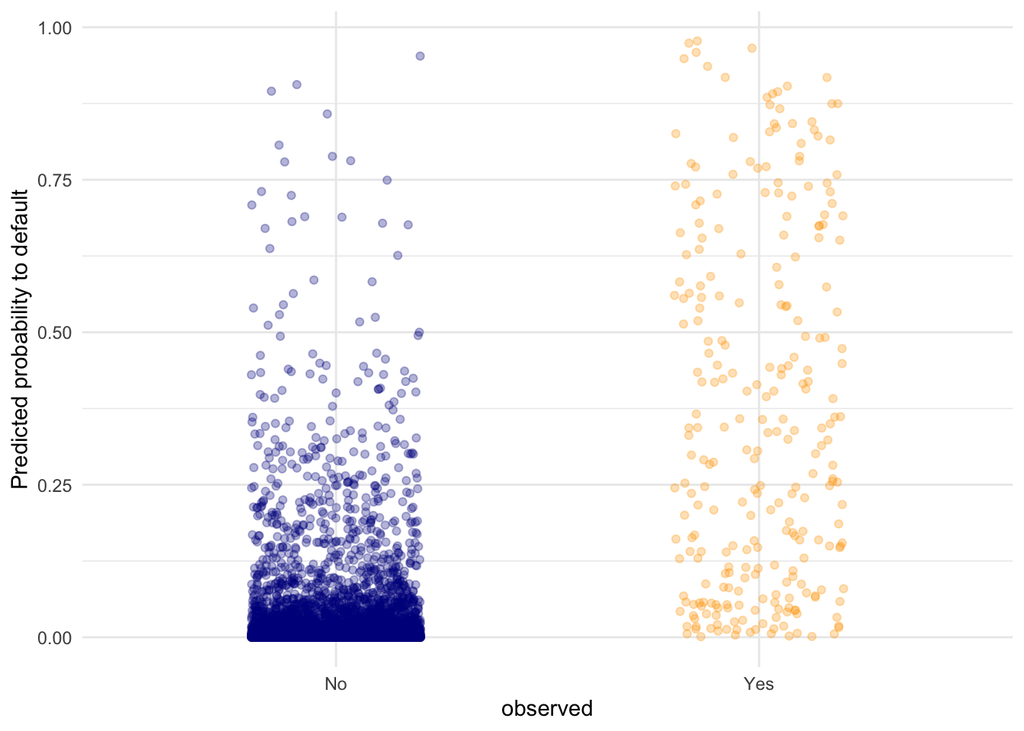

```r
tibble(observed  = train$default,
       predicted = predict(fit, type = "response")) %>%
  ggplot(aes(y = predicted, x = observed, colour = observed)) +
  geom_point(position = position_jitter(width = 0.2), alpha = .3) +
  scale_colour_manual(values = c("dark blue", "orange"), guide = "none") +
  theme_minimal() +
  labs(y = "Predicted probability to default")
```

One advantage of parametric procedures like logistic regression is that we get parameters (coefficients) we can interpret.

11. **Look at the coefficients of the `fit` model and interpret the coefficient for `balance`. What would the probability of default be for a person who is not a student, has an income of 40000, and a balance of 3000 dollars at the end of each month? Is this what you expect based on the plots we’ve made before?**

```r
coefs <- coef(fit)
coefs["balance"]
```

```
##     balance
## 0.005728527
```

The higher the `balance`, the higher the log-odds of defaulting. To be more precise: each dollar increase in `balance` increases the log-odds of defaulting by 0.0057 Let’s study all coefficients.

```r
coefs
```

```
##   (Intercept)       student       balance        income
## -1.063443e+01 -7.718385e-01  5.728527e-03 -1.168747e-06
```

Now, if we would like to calculate the predicted logodds of default for a person who is not a student (0 times the coefficient for `student`), has an income of 40000 (40000 multiplied with the coefficient for `income`) and a balance of 3000 dollars (3000 multiplied with the coefficient for `balance`), we can do the following to calculate the logodds directly:

```r
logodds <- coefs[1] + 0*coefs[2] + 40000*coefs[4] + 3000*coefs[3]
```

We can then convert the logodds to a probability by

```r
1 / (1 + exp(-logodds))
```

```
## (Intercept)
##   0.9985054
```

or as

```r
plogis(logodds)
```

```
## (Intercept)
##   0.9985054
```

There is a probability of .999 of defaulting. This is in line with the plots we have seen before. this new data point would be all the way to the right.

## Visualising the effect of the balance variable

In two steps, we will visualise the effect `balance` has on the predicted default probability.

12. **Create a data frame called `balance_df` with 3 columns and 500 rows: `student` always 0, `balance` ranging from 0 to 3000, and `income` always the mean income in the `train` dataset.**

```r
balance_df <- tibble(
  student = rep(0, 500),
  balance = seq(0, 3000, length.out = 500),
  income  = rep(mean(train$income), 500)
)
```

13. **Use this dataset as the `newdata` in a `predict()` call using `fit` to output the predicted probabilities for different values of `balance`. Then create a plot with the `balance_df$balance` variable mapped to x and the predicted probabilities mapped to y. Is this in line with what you expect?**

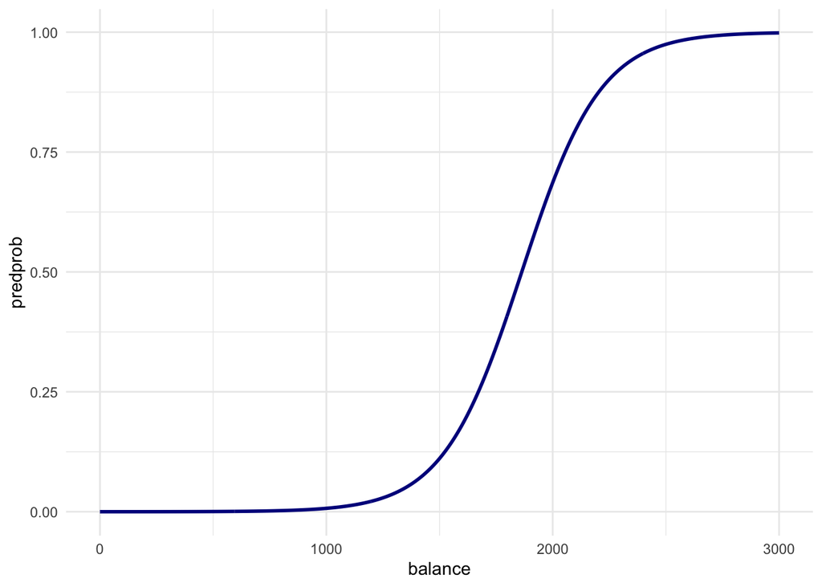

```r
balance_df$predprob <- predict(fit,
                               newdata = balance_df,
                               type = "response")

balance_df %>%
  ggplot(aes(x = balance, y = predprob)) +
  geom_line(col = "dark blue", size = 1) +
  theme_minimal()
```

Just before a `balance` of 2000 dollars in the first plot is where the ratio of defaults vs non-defaults is 50/50. This line is exactly what we would expect.

14. **Create a confusion matrix just as the one for the KNN models by using a cutoff predicted probability of 0.5. Does logistic regression perform better?**

```r
pred_prob <- predict(fit, newdata = test, type = "response")
pred_lr   <- factor(pred_prob > .5, labels = c("No", "Yes"))

confusionMatrix(pred_lr, test$default)
```

```
## Confusion Matrix and Statistics
##
##           Reference
## Prediction   No  Yes
##        No  1923   47
##        Yes   10   19
##
##                Accuracy : 0.9715
##                  95% CI : (0.9632, 0.9783)
##     No Information Rate : 0.967
##     P-Value [Acc > NIR] : 0.1429
##
##                   Kappa : 0.3877
##
##  Mcnemar's Test P-Value : 1.858e-06
##
##             Sensitivity : 0.9948
##             Specificity : 0.2879
##          Pos Pred Value : 0.9761
##          Neg Pred Value : 0.6552
##              Prevalence : 0.9670
##          Detection Rate : 0.9620
##    Detection Prevalence : 0.9855
##       Balanced Accuracy : 0.6414
##
##        'Positive' Class : No
##
```

End of Practical